# ACTIVIDAD 2 - UD2

# Actividad 2 - UD2

Carga el dataset **titanic** con el comando y haz un sumario

```r
 #install.packages("titanic")
 library(titanic)
 library("ggplot2")
 library(dplyr)
 data("titanic_train")
 titanic_data <- titanic_train
 head(df)
```

```
1 function (x, df1, df2, ncp, log = FALSE)
2 {
3     if (missing(ncp))
4         .Call(C_df, x, df1, df2, log)
5     else .Call(C_dnf, x, df1, df2, ncp, log)
6 }
```

```r
 str(df)
```

```
function (x, df1, df2, ncp, log = FALSE)
```

- Transforma las variables que sean factores en factores. Si son ordinales usa *ordered* para crear factores ordenados. Recuerda usar lapply.
- Representa en un qplot la edad frente a la tarifa, y en un segundo qplot lo mismo pero con la clave de la clase en la que viajaban. Represéntalo a su vez factorizándolo por *Sex* y *Embarked*
- Pinta un boxplot de la edad agrupado según *Sex*
- Pinta un barplot que represente la supervivencia en cada *Pclass* coloreando las barras según esta
- Pinta la supervivencia en función de la categoría *Sex*, ¿qué observas?
- Pinta la supervivencia en función de la categoría *Pclass*, ¿qué se aprecia?
- Crea un histograma de *Age*, ¿qué observas?
- Crea una agrupación de los datos usando `dplyr` de *Sex* y *Pclass*. Haz sumarios de media, conteo y mediana. ¿Qué podrías decir de los resultados? ¿Hay suficiente muestra para sacar conclusiones en todas las categorías creadas al combinar la edad y la clase?

[output not shown]

- Transforma las variables que sean factores en factores. Si son ordinales usa *ordered* para crear factores ordenados. Recuerda usar lapply. Serían:Survived, Pclass, Sex.

```r
#titanic_data$Sex
#lapply puede trabajar con listas o vectores que aplica una función a cada elemento de una lista o vector.
factor_rows<-c("Sex","Cabin","Ticket","Name","Embarked","Survived")
titanic_data[factor_rows]<-lapply(titanic_data[factor_rows], factor)
ordered_rows<-c("Pclass","SibSp","Parch")
titanic_data[ordered_rows]<-lapply(titanic_data[ordered_rows], ordered)
titanic_data
```

| PassengerId | Survived | Pclass | Name | Sex | Age | SibSp | Parch | Ticket | Fare | Cabin | Embarked |
| --- | --- | --- | --- | --- | --- | --- | --- | --- | --- | --- | --- |
| 1 | 0 | 3 | Braund, Mr. Owen Harris | male | 22.00 | 1 | 0 | A/5 21171 | 7.2500 |  | S |
| 2 | 1 | 1 | Cumings, Mrs. John Bradley (Florence Briggs Thayer) | female | 38.00 | 1 | 0 | PC 17599 | 71.2833 | C85 | C |
| 3 | 1 | 3 | Heikkinen, Miss. Laina | female | 26.00 | 0 | 0 | STON/O2. 3101282 | 7.9250 |  | S |
| 4 | 1 | 1 | Futrelle, Mrs. Jacques Heath (Lily May Peel) | female | 35.00 | 1 | 0 | 113803 | 53.1000 | C123 | S |
| 5 | 0 | 3 | Allen, Mr. William Henry | male | 35.00 | 0 | 0 | 373450 | 8.0500 |  | S |
| 6 | 0 | 3 | Moran, Mr. James | male | NA | 0 | 0 | 330877 | 8.4583 |  | Q |
| 7 | 0 | 1 | McCarthy, Mr. Timothy J | male | 54.00 | 0 | 0 | 17463 | 51.8625 | E46 | S |
| 8 | 0 | 3 | Palsson, Master. Gosta Leonard | male | 2.00 | 3 | 1 | 349909 | 21.0750 |  | S |
| 9 | 1 | 3 | Johnson, Mrs. Oscar W (Elisabeth Vilhelmina Berg) | female | 27.00 | 0 | 2 | 347742 | 11.1333 |  | S |
| 10 | 1 | 2 | Nasser, Mrs. Nicholas (Adele Achem) | female | 14.00 | 1 | 0 | 237736 | 30.0708 |  | C |

[output cut: 881 more lines]

Representa en un qplot la edad frente a la tarifa, y en un segundo qplot lo mismo pero con la clave de la clase en la que viajaban.

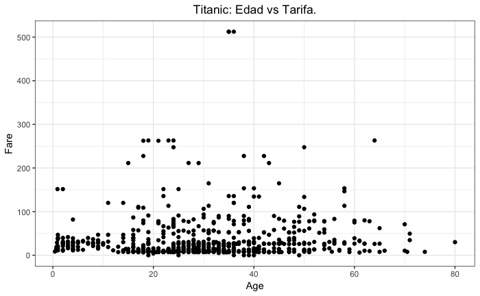

```r
ggplot(titanic_data, aes(x=Age, y=Fare)) +
  geom_point(na.rm=TRUE) +
  ggtitle ("Titanic: Edad vs Tarifa.") +
  theme_bw() +
  theme(plot.title = element_text(hjust = 0.5))
```

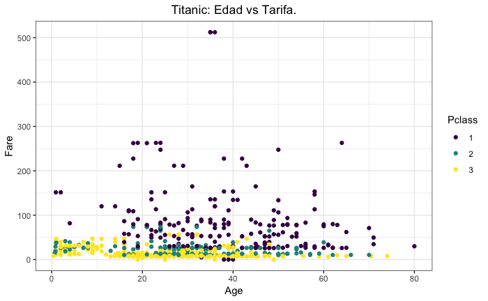

```r
#con clase en la que viajaban
ggplot(titanic_data, aes(x=Age, y=Fare, color=Pclass)) +
  geom_point(na.rm=TRUE) +
  ggtitle ("Titanic: Edad vs Tarifa.") +
  theme_bw() +
  theme(plot.title = element_text(hjust = 0.5))
```

```r
NA
```

Represéntalo a su vez factorizándolo por *Sex* y *Embarked*

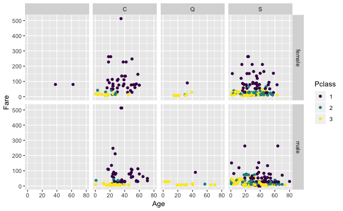

```r
ggplot(titanic_data, aes(x=Age, y=Fare, colour=Pclass)) +
  geom_point(na.rm=TRUE) +
  facet_grid(Sex ~ Embarked)
```

- Pinta un boxplot de la edad agrupado según *Sex*

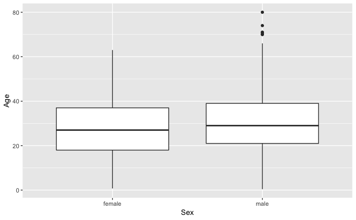

```r
p <- ggplot(titanic_data, aes(Sex, Age))
p + geom_boxplot()
```

- Pinta un barplot que represente la supervivencia en cada *Pclass* coloreando las barras según esta

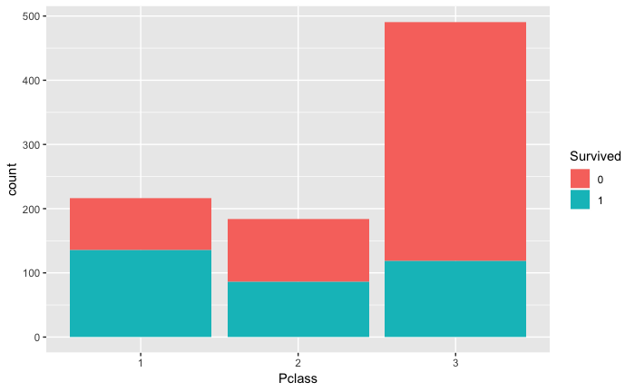

```r
ggplot(titanic_data, aes(Pclass, fill=Survived))+geom_bar()
```

- Pinta la supervivencia en función de la categoría *Sex*, ¿qué observas?
- Pinta la supervivencia en función de la categoría *Pclass*, ¿qué se aprecia?

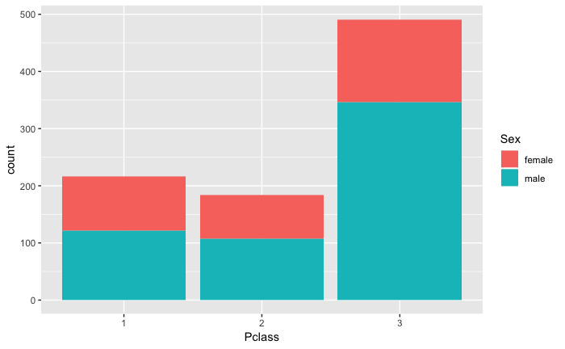

```r
ggplot(titanic_data, aes(Pclass, fill=Sex))+geom_bar()
```

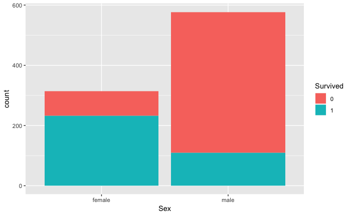

```r
ggplot(data=titanic_data, aes(Sex, fill=Survived)) +
    geom_bar()
```

Han sobrevivido muchas mas mujeres en total y en %.

- Crea un histograma de *Age*, ¿qué observas?

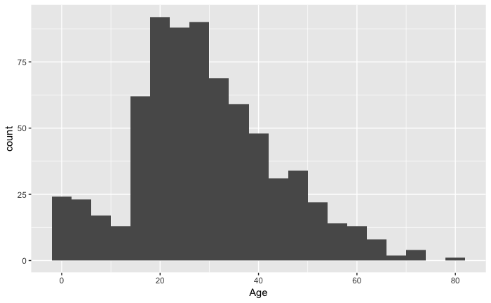

```r
ggplot(titanic_data, aes(x=Age)) + geom_histogram(binwidth=4,na.rm = TRUE) #establece el ancho de cada partición
```

# La mayor parte de la gente se contentraba entre los 18 y los 40 años.

- Crea una agrupación de los datos usando `dplyr` de *Sex* y *Pclass*. Haz sumarios de media, conteo y mediana. ¿Qué podrías decir de los resultados? ¿Hay suficiente muestra para sacar conclusiones en todas las categorías creadas al combinar la edad y la clase?

```r
titanic_data$DummySurvived <- as.numeric(titanic_data$Survived) -1 #hay que crear una columna tipo int, ya que la original es un factor.
titanic_data %>%
    group_by(Sex,Pclass) %>%
    summarise(mean(DummySurvived),median(DummySurvived), Conteo=n() )
```

| Sex | Pclass | mean(DummySurvived) | median(DummySurvived) | Conteo |
| --- | --- | --- | --- | --- |
| female | 1 | 0.9680851 | 1.0 | 94 |
| female | 2 | 0.9210526 | 1.0 | 76 |
| female | 3 | 0.5000000 | 0.5 | 144 |
| male | 1 | 0.3688525 | 0.0 | 122 |
| male | 2 | 0.1574074 | 0.0 | 108 |
| male | 3 | 0.1354467 | 0.0 | 347 |